# Estimating Means with Confidence

b06208001 龔泓愷

2018年11月9日

## Q1118

1. **0.2**  
   The standard error of the mean of foot lenghs of women is smaller than thoe one of men because the sample size is **LARGER**.

```r
n1 = 64; mu1 = 27.5; sd1 = 2
n2 = 100; mu2 = 24; sd2 = 2
se2 = sd2/sqrt(n2); se2
```

```
## [1] 0.2
```

2. **0.3202**

```r
mud = mu1 - mu2;mud
```

```
## [1] 3.5
```

```r
sed = sqrt(sd1^2/n1 + sd2^2/n2);sed
```

```
## [1] 0.3201562
```

## Q1132

Group1：Taking Zinc  
Group2：Taking Placebo

```r
n1 = 25;n2 = 23
mu1 = 4.5; mu2 = 8.1
sd1 = 1.6/sqrt(25); sd2 = 1.8/sqrt(23)
t <- qt((1 - 0.95)/2, df = 24, lower.tail = F);t
```

```
## [1] 2.063899
```

1. **[3.8396, 5.1604]**

```r
mu1 - t * sd1; mu1 + t * sd1
```

```
## [1] 3.839552
```

```
## [1] 5.160448
```

2. **[7.3254, 8.8746]**

```r
mu2 - t * sd2; mu2 + t * sd2
```

```
## [1] 7.325365
```

```
## [1] 8.874635
```

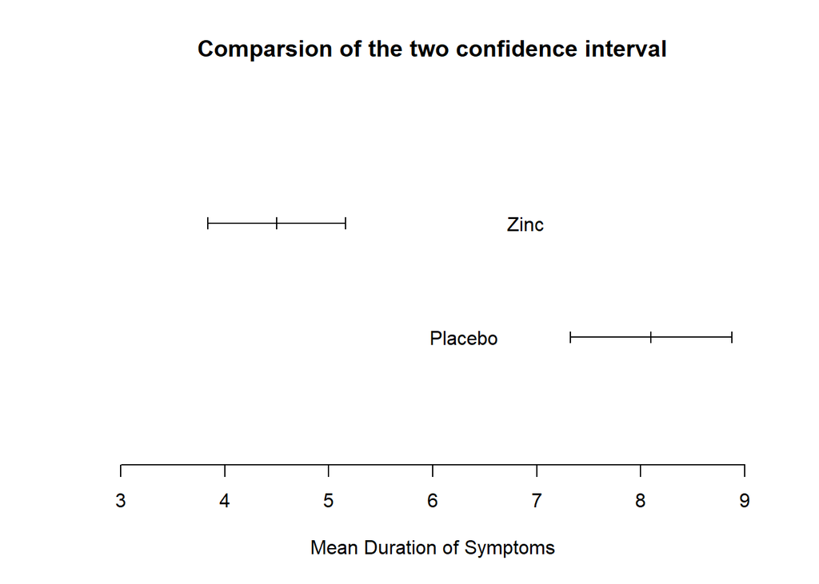

```r
plot(c(0,3),type='n',xlim=c(3,9),xlab='Mean Duration of Symptoms',ylab='',axes=F,
     main='Comparsion of the two confidence interval')

lines(c(3.8396,5.1604),c(2,2))
text(6.9,2,labels='Zinc')
lines(c(mu1 - t * sd1, mu1 - t * sd1),c(1.95,2.05))
lines(c(mu1, mu1),c(1.95,2.05))
lines(c(mu1 + t * sd1, mu1 + t * sd1),c(1.95,2.05))

lines(c(7.3254, 8.8746),c(1,1))
text(6.3,1,labels='Placebo')
lines(c(mu2 - t * sd2, mu2 - t * sd2),c(0.95,1.05))
lines(c(mu2, mu2),c(0.95,1.05))
lines(c(mu2 + t * sd2,mu2 + t * sd2),c(0.95,1.05))

axis(1)
```

## Q1150

1. **[0.8172, 2.7828]**  
   The interval tells us that we are of 95% confdence that the mean of difference ideal & actual heights of women aged 18~29 is between 0.8172 & 2.7828 inches.

```r
n = 20;mu1 = 66.7; mu2 = 64.9; dbar = 1.8; sd = 2.1
se = sd/sqrt(20);se
```

```
## [1] 0.4695743
```

```r
t = qt((1 - 0.95)/2, df = 19, lower.tail = F)
CI.up = dbar + t * se; CI.up
```

```
## [1] 2.78283
```

```r
CI.low = dbar - t* se; CI.low
```

```
## [1] 0.8171697
```

2. Since the sample size is relatively small, it should meet condition1 for calculation in part(a)
3. ‘All women’ in the sentence is wrong.  
   It should be **on average**, women aged 18~29 would like to be taller.
4. NO  
   The condition on page428 is not appropriate for this condition, since it requires a larger sample size.

## Q1160

1. Unpooled:**[-1.7274, 15.0607]**  
   The data is approximately bell-shaped without skewness and outliers although the sample size isn’t large enough.  
   Therefore, computing the 95% confidence interval is justified.

```r
Group1 <- c(72,84,66,72,62,84,76,60);n1 = 8;mu1 = mean(Group1);sd1 = sd(Group1)
Group2 <- c(62,72,60,63,75,64,60,52,64,80,68,64);n2 = 12;mu2 = mean(Group2);sd2 = sd(Group2)
t.test(Group1, Group2, alternative = 'two.sided', var.equal = F, paired = F, conf.level = 0.95)
```

```
##
##  Welch Two Sample t-test
##
## data:  Group1 and Group2
## t = 1.7156, df = 13.014, p-value = 0.1099
## alternative hypothesis: true difference in means is not equal to 0
## 95 percent confidence interval:
##  -1.727387 15.060720
## sample estimates:
## mean of x mean of y
##  72.00000  65.33333
```

2. Pooled:**[-1.1652, 14.4985]**

```r
sp = sqrt(((n1-1)*sd1^2 + (n2-1)*sd2^2)/(n1+n2-2));sp
```

```
## [1] 8.167234
```

```r
se.pooled = sp*sqrt(1/n1 + 1/n2);se.pooled
```

```
## [1] 3.727815
```

```r
df.pooled = n1 + n2 - 2;df.pooled
```

```
## [1] 18
```

```r
t <- qt((1-0.95)/2, df = df.pooled, lower.tail = F);t
```

```
## [1] 2.100922
```

```r
CI.up = (mu1 - mu2) + t * se.pooled;CI.up
```

```
## [1] 14.49852
```

```r
CI.low = (mu1 - mu2) - t * se.pooled;CI.low
```

```
## [1] -1.165182
```

```r
#T-test var equal決定是不是pooled
t.test(Group1, Group2, alternative = 'two.sided', var.equal = T, paired = F, conf.level = 0.95)
```

```
##
##  Two Sample t-test
##
## data:  Group1 and Group2
## t = 1.7884, df = 18, p-value = 0.09056
## alternative hypothesis: true difference in means is not equal to 0
## 95 percent confidence interval:
##  -1.165182 14.498515
## sample estimates:
## mean of x mean of y
##  72.00000  65.33333
```

## Q1178

1. **6.4106 seconds**

```r
n1 = 16;mu1 = 113.75;sd1 = 22.64#Alcohol
n2 = 16;mu2 = 99.87;sd2 = 12.04#Placebo
se = sqrt(sd1^2/n1 + sd2^2/n2);se
```

```
## [1] 6.410593
```

2. **[0.5852, 27.1748]**

```r
t <- qt((1-0.95)/2, df = 22, lower.tail = F);t
```

```
## [1] 2.073873
```

```r
CI.up = (mu1 - mu2) + t * se;CI.up
```

```
## [1] 27.17476
```

```r
CI.low = (mu1 - mu2) - t * se;CI.low
```

```
## [1] 0.5852443
```

3. On the basis of part(b), we have 95% confidence to say that the populationmeans for the two groups are **different** since the intervals do not cover 0.
4. It is reasonable to assume that both-populations are bell-shaped beacause most people take about the same amount of time to read out all the colours.  
   Therefore, computing the 95% confidence is justified although the samplee size is not large enough.

## Q1180

1. **Paired Data** It is better to use paired data because two variables of interest are measured for each individual.
2. A rnadom order is important because each individual might learn something in the first measurement and improve one’s performance in the second measurement.
3. **[-0.0402, 2.1735]**

```r
Dominant = c(22,19,18,17,15,16,16,20,17,15,17,17,14,20,26)
Undominant = c(18,15,13,16,17,16,14,16,20,15,17,17,16,18,25)
t.test(Dominant, Undominant, alternative = "two.sided", paired = T, var.equal = F, conf.level = 0.90)#paired = T成對資料與x = diff, y = NULL結果一樣
```

```
##
##  Paired t-test
##
## data:  Dominant and Undominant
## t = 1.6974, df = 14, p-value = 0.1117
## alternative hypothesis: true difference in means is not equal to 0
## 90 percent confidence interval:
##  -0.04018838  2.17352171
## sample estimates:
## mean of the differences
##                1.066667
```

4. Since the intervals cover 0, we can not conclude whether dexterity is better for the dominant hand.

## R Function Practice

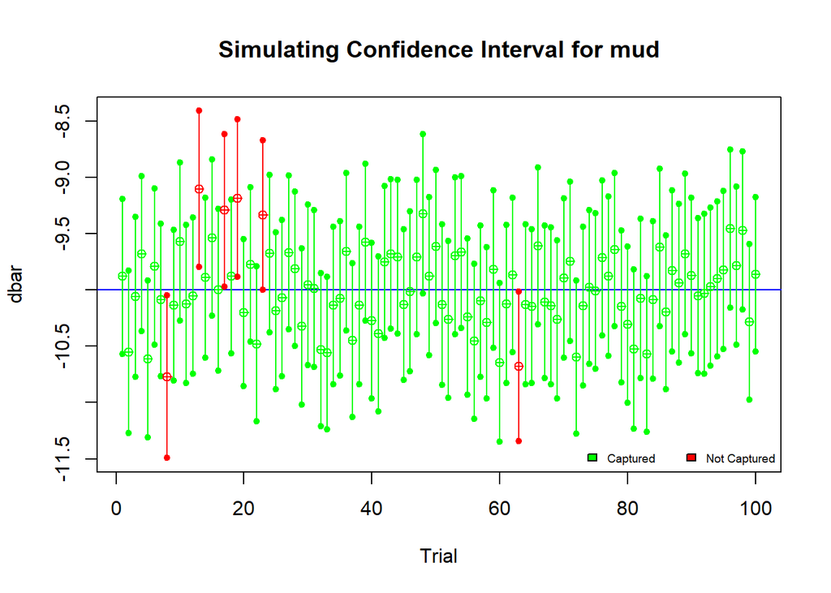

```
## $Trial
## [1] 100
##
## $Sample.Size
## [1] 1000
##
## $Population.Differences.Mean
## [1] -10
##
## $Population.Differences.sd
## [1] 11.18034
##
## $Confidence
## [1] 0.95
##
## $NO.Captured
## [1] 6
```

```r
Simd_CI <- function (n, mu1, mu2, sd1, sd2, m, conf.level){
  #成對樣本只需要一個n
  prob <- (1 - conf.level)/2#雙尾信賴區間
  t.value <- qt(prob, df = n - 1, lower.tail = F)#找T-Value

  dbar = c()
  se.d = c()
  mud = mu1 - mu2

  CI.half = c()
  CI.up = c()
  CI.lower = c()
  Check = c()#有沒有包含理論值的mud

  #取樣M次，每次n人
  for (i in 1:m) {
    x1 <- rnorm(n, mean = mu1, sd = sd1)
    x2 <- rnorm(n, mean = mu2, sd = sd2)
    dbar[i] <- mean(x1 - x2)
    se.d[i] <- sd(x1 - x2)/sqrt(n)

    #Calculate CIs
    CI.half[i] <- t.value * se.d[i]
    CI.up[i] <- dbar[i] + CI.half[i]
    CI.lower[i] <- dbar[i] - CI.half[i]

    if (CI.up[i] > mud & CI.lower[i] < mud){
      Check[i] <- 1
    }else {
      Check[i] <- 0
    }
  }

  plot(c(CI.up, CI.lower), type = 'n', #n是不畫圖，給空框架
       pch = 19, xlim = c(1, m), xlab = 'Trial',
       ylab = expression(dbar))

  abline(h = mud, col = 'blue')

  #Check whether each CI captures the mud
  for (i in 1:m){
    if (Check[i] == 1) {
      points(i, dbar[i], col = 'green', pch = 10)
      points(i, CI.up[i], col = 'green', pch = 20)
      points(i, CI.lower[i], col = 'green', pch = 20)
      lines(c(i, i), c(CI.lower[i], CI.up[i]), col = 'green', pch = 19)
    }else{
      points(i, dbar[i], col = 'red', pch = 10)
      points(i, CI.up[i], col = 'red', pch = 20)
      points(i, CI.lower[i], col = 'red', pch = 20)
      lines(c(i, i), c(CI.lower[i], CI.up[i]), col = 'red', pch = 19)
    }
  }

  title('Simulating Confidence Interval for mud')

  legend('bottomright', cex = 0.6, bty = 'n', ncol = 2,
         c('Captured', 'Not Captured'),
         fill = c('green', 'red'))

  NO.Captured <- m-sum(Check)
  RESULT <- list(Trial = m, Sample.Size = n,
                 Population.Differences.Mean = mud,
                 Population.Differences.sd  = sqrt(sd1^2 + sd2^2),
                 Confidence = conf.level,
                 NO.Captured = NO.Captured)

  return(RESULT)
}
Simd_CI(1000, 80, 90, 10, 5, 100, 0.95)
```